# BIOS 667 - Lecture 14: Generalized Linear Mixed Effects Models (Ch. 14)

Fitzmaurice, Laird & Ware (2011) - Applied Longitudinal Data Analysis

Naim Rashid

## Lecture Objectives

- Position **GLMMs** within the marginal-mixed-transition modeling triad
- Derive the GLMM likelihood and understand why **integrals over random effects** drive computation
- Fit and interpret subject-specific effects for binary and count outcomes in R
- Master the **critical distinction** between marginal and conditional interpretations
- Work a real FLW Ch. 14 Case Study (seizure-count data) end to end
- Diagnose model fit, test variance components correctly, and report results honestly

## Notation reference

| Symbol | Meaning |
| --- | --- |
| $Y_{ij}$ | response for subject $i$ at occasion $j$ (scalar) |
| $\mathbf{Y}_i$ | response vector for subject $i$ $(n_i \times 1)$ |
| $\mathbf{X}_i,\ \boldsymbol\beta$ | fixed-effect design $n_i \times p$ and coefficients |
| $\mathbf{Z}_i,\ \mathbf{b}_i$ | random-effect design and random effects, $\mathbf{b}_i \sim N(0, G)$ |
| $G$ | between-subject random-effects covariance (FLW’s letter, Ch. 8) |
| $R_i$ | within-subject residual covariance, $\boldsymbol\varepsilon_i \sim N(0, R_i)$ |
| $\Sigma_i = \mathbf{Z}_i G \mathbf{Z}_i^\top + R_i$ | marginal (total) covariance $\operatorname{Cov}(\mathbf{Y}_i)$ for subject $i$ |
| $\rho$ | correlation parameter (AR(1), exchangeable) |

Indices: $i$ subject $1,\dots,N$; $j$ occasion/time $1,\dots,n_i$ ($n$ when balanced); $k$ state (transition models); $g$ group. **Bold** = vector or matrix.

## Notation (this lecture)

| Symbol | Meaning |
| --- | --- |
| $Y_{ij}\mid \mathbf{b}_i$ | outcome conditional on the random effects $\mathbf{b}_i$ |
| $g(\cdot)$ | link: $g\!\left(E[Y_{ij}\mid \mathbf{b}_i]\right) = X_{ij}\beta + Z_{ij}\mathbf{b}_i$ |
| $\mathbf{b}_i \in \mathbb{R}^q$ | subject-specific random effects, $\mathbf{b}_i \sim N_q(0, G)$ |
| $\pi_{ij}$ | binary response probability (recall L11) |
| $\phi$ | dispersion parameter (recall L11) |
| $f_G(\mathbf{b}_i)$ | random-effects density, $N(\mathbf{b}_i;\,0,G)$ |

## Roadmap

**Part I (Day 1) - Concepts**

1. Motivating examples and the model hierarchy
2. GEE vs GLMM: terminology, missing-data asymmetry
3. GLMM anatomy and the likelihood integral
4. Binary random-intercept GLMM: subject-specific interpretation
5. Conditional vs marginal effects; Jensen; the Zeger approximation

**Part II (Day 2) - Worked machinery**

6. Predictions taxonomy (subject / at-RE / true marginal)
7. Real Case Study: FLW seizure-count data (Table 14.6)
8. Overdispersion, variance-component testing, diagnostics
9. Convergence recipe, pitfalls, reporting

# Part I (Day 1): Concepts

## Where We Are

| Chapter | Topic | Focus |
| --- | --- | --- |
| 11 | Generalized linear models | Discrete outcomes, one observation |
| 12-13 | Marginal models + GEE | Population-average inference |
| **14** | **GLMMs** | **Subject-specific inference for discrete outcomes** |

## GLMMs Excel When

- Subject heterogeneity drives the association
- Covariate effects are interpreted **conditional** on latent subject traits
- Predicted subject trajectories or shrinkage estimates are needed
- Interest is at the **individual level**

## GEE vs GLMM: Translation Guide

| **GEE (marginal)** | **GLMM (conditional)** |
| --- | --- |
| Population-averaged effect | Subject-specific effect |
| Working correlation $\operatorname{Corr}_i(\alpha)$ | Correlation induced from $G$ |
| Robust (sandwich) SE | Model-based SE |
| $\text{OR}_{\text{population}}$ | $\text{OR}_{\text{conditional}}$ |
| “Average over people” | “Within a person, holding $\mathbf{b}_i$ fixed” |
| Valid inference needs **MCAR** | Valid inference under **MAR** |

**Key insight:** Both answer valid but *different* scientific questions.

## When to Choose Which

| Choose **GLMM** when | Choose **GEE** when |
| --- | --- |
| Subject-specific effect is the question | Population-averaged effect is the question |
| Need individual trajectory predictions | Covariance is a nuisance |
| Heterogeneity is scientifically interesting | Want robust, low-assumption inference |
| Cluster sizes adequate ($n_i \geq 5$ for binary) | Very small clusters ($n_i = 2$-$3$), sparse binary |
| Missing data plausibly **MAR** | Missing data plausibly **MCAR** |

## Why GLMMs Matter: Asthma Example

| Analysis | Treatment OR | Interpretation |
| --- | --- | --- |
| GEE (marginal) | 1.8 | Population: steroid raises odds of control 80% |
| GLMM (conditional) | 2.4 | Within child: steroid raises odds 140% |

**Why do they differ?** Averaging the nonlinear logit over between-child variability shrinks the **population-averaged** OR toward 1 (non-collapsibility / Jensen). The subject-specific OR is larger. This is **attenuation, not differential benefit.**

**Note**

Forward reference: we make this precise on the Jensen slides and quantify it with the Zeger approximation (a Ch. 16 result).

## Non-collapsibility (define it now)

> **Non-collapsibility:** an odds ratio computed within strata can differ from the odds ratio computed in the pooled (marginal) population *even when there is no confounding.*
- Risk differences and (log) rate ratios are collapsible; **odds ratios are not**
- Mixing subjects with different baseline risk ($\mathbf{b}_i$) shifts the marginal OR toward 1
- This is a property of the **odds-ratio scale**, not a bias

## Model Hierarchy

**Level 1** (conditional on $\mathbf{b}_i \in \mathbb{R}^q$):
$$Y_{ij} \mid \mathbf{b}_i \sim \text{EF}(\mu_{ij}, \phi), \quad g(\mu_{ij}) = \eta_{ij} = X_{ij}\beta + Z_{ij}\mathbf{b}_i$$

**Level 2:**
$$\mathbf{b}_i \sim N(0, G)$$

- **EF** = exponential-family distribution (binomial, Poisson, …; recall L11)
- Grounding links: **logit** for binary $\pi_{ij}$, **log** for Poisson rates

## Jensen’s Inequality and Marginal Means

**Marginal mean:** $E(Y_{ij}) \neq g^{-1}(X_{ij}\beta)$ because of **Jensen’s inequality**:

$$E\!\left[g^{-1}(\eta + b)\right] \neq g^{-1}\!\left(E[\eta + b]\right) \quad \text{for nonlinear } g^{-1}$$

**Key:** random effects create heterogeneity; averaging over it **attenuates** effects on the probability scale.

**Note**

The explicit conditional-vs-marginal numeric contrast (next two slides) previews **FLW Ch. 16** (Fig. 16.1). Ch. 14 itself establishes the conditional interpretation; we show the contrast now to motivate it.

## Jensen’s Inequality: Concrete Numerical Example

**Setup:** logistic model, random intercept $b_i$ taking three equally likely values $\{-2, 0, 2\}$.

At $\eta = 0$:

| $b_i$ | $\eta + b_i$ | $P(Y=1 \mid b_i) = \text{expit}(\eta + b_i)$ |
| --- | --- | --- |
| -2 | -2 | 0.119 |
| 0 | 0 | 0.500 |
| +2 | +2 | 0.881 |

Plug-in at $b=0$: 0.500. Average of probabilities: $(0.119+0.500+0.881)/3 = 0.500$. **They match here** because $\eta=0$ is symmetric.

## Jensen’s Inequality: The Calculation

Now try $\eta = 1$:

| $b_i$ | $\eta + b_i$ | $P(Y=1 \mid b_i)$ |
| --- | --- | --- |
| -2 | -1 | 0.269 |
| 0 | 1 | 0.731 |
| +2 | 3 | 0.953 |

- **Plug-in at $b=0$:** $\text{expit}(1) = 0.731$
- **Average the probabilities:** $(0.269+0.731+0.953)/3 = 0.651$

**Difference: 8 percentage points.** This is why `re.form=NA` does NOT give marginal predictions.

**Quick Check**

Why is the true marginal probability (0.651) *lower* than the plug-in at $b=0$ (0.731)?

**Answer:** above $\eta = 0$ the logistic curve is concave, so $E[g(X)] \leq g(E[X])$. The $b_i=-2$ subject pulls the average down more than $b_i=+2$ can pull it up (the curve flattens near 1).

## Likelihood Challenge

**Subject-specific contribution:**
$$L_i(\beta, G) = \int_{\mathbb{R}^q} \prod_{j=1}^{n_i} f(y_{ij} \mid \mathbf{b}_i;\, \beta)\; f_G(\mathbf{b}_i)\; d\mathbf{b}_i$$

- $f_G(\mathbf{b}_i) = N(\mathbf{b}_i;\, 0, G)$ is the random-effects density
- **No closed form** when $f(\cdot\mid\mathbf{b}_i)$ is non-Gaussian
- This integral is what makes GLMM fitting hard

## Estimation: ML via Numerical Integration

```
Random intercept only, moderate n_i (>=5)?
  -> Laplace approximation (lme4 default, nAGQ = 1): fast, usually adequate
Random slopes, or small/sparse clusters?
  -> Adaptive Gauss-Hermite quadrature (nAGQ = 5-50): more accurate
Complex G, sparse data, full uncertainty wanted?
  -> Bayesian MCMC (brms, MCMCglmm)
```

**Note**

**Recipe:** start at Laplace, confirm with a few quadrature points, escalate only if estimates move. FLW’s Ch. 14 case studies all use **ML via 50-point adaptive Gaussian quadrature** (PROC GLIMMIX).

**Warning**

**PQL / MQL** are **Ch. 15 (approximate methods)**, not Ch. 14 estimation. They are biased for sparse binary data; we treat them next chapter.

## R Setup

```r
suppressPackageStartupMessages({
  library(dplyr)
  library(tidyr)
  library(ggplot2)
  library(lme4)
  library(emmeans)
  library(broom.mixed)
  library(patchwork)
})
theme_set(theme_minimal(base_size = 16))
```

## R Setup

## Example 1: Binary Asthma Control Trial (simulated)

**Warning**

**Simulated to isolate a teaching point** (the conditional-vs-marginal gap on the binary/logit scale). The real FLW Ch. 14 Case Study is the seizure data, worked in Part II.

- 120 children, quarterly visits for 2 years
- Outcome: **controlled asthma** (1) vs uncontrolled (0)
- Predictors: treatment (steroid vs usual care), visit time, baseline severity
- Random intercept captures latent propensity for control

## Example 1: Data Simulation

```r
set.seed(667)
n_subj <- 120; visits <- 8
asthma_dat <- tibble(
  id    = rep(1:n_subj, each = visits),
  visit = rep(0:(visits - 1), times = n_subj),
  weeks = rep(0:(visits - 1), times = n_subj) * 12,
  treat = factor(rep(sample(c("Steroid","Usual"), n_subj, replace = TRUE), each = visits)),
  severity = rep(sample(c("Mild","Moderate","Severe"), n_subj, replace = TRUE,
                        prob = c(0.5, 0.35, 0.15)), each = visits)
) %>%
  mutate(
    sev_score = case_when(severity == "Mild" ~ 0, severity == "Moderate" ~ 0.6, TRUE ~ 1.2),
    treat_num = if_else(treat == "Steroid", 0.6, 0),   # TRUTH: steroid log-OR = 0.6
    time_eff  = 0.05 * weeks / 12,                      # TRUTH: time log-OR per yr = 0.05
    rand_int  = rep(rnorm(n_subj, sd = 0.9), each = visits),  # TRUTH: RE intercept SD = 0.9
    linpred   = -1 + treat_num + time_eff - 0.8 * sev_score + # TRUTH: severity log-OR = -0.8
                0.15 * treat_num * (weeks / 12) + rand_int,    # TRUTH: treat x time = 0.15
    prob      = plogis(linpred),
    control   = rbinom(n_subj * visits, size = 1, prob = prob)
  )
asthma_dat$treat <- relevel(asthma_dat$treat, ref = "Usual")
```

## Example 1: Data Simulation

## Fit the Random-Intercept Logistic GLMM

```r
glmm_fit <- glmer(
  control ~ treat * weeks + severity + (1 | id),
  data = asthma_dat,
  family = binomial(link = "logit")
)
broom.mixed::tidy(glmm_fit, effects = "fixed", conf.int = TRUE) %>%
  dplyr::select(term, estimate, std.error, conf.low, conf.high)
```

**Note**

Recovered steroid log-OR 1 (truth 0.6) and random-intercept SD 1.04 (truth 0.9): the conditional estimates track the DGP.

## Fit the Random-Intercept Logistic GLMM

```
# A tibble: 6 × 5
  term               estimate std.error conf.low conf.high
  <chr>                 <dbl>     <dbl>    <dbl>     <dbl>
1 (Intercept)        -1.20      0.218   -1.63     -0.771
2 treatSteroid        1.00      0.306    0.404     1.60
3 weeks               0.00712   0.00116  0.00484   0.00939
4 severityModerate   -0.0986    0.272   -0.632     0.435
5 severitySevere     -1.29      0.389   -2.05     -0.523
6 treatSteroid:weeks -0.00409   0.00421 -0.0123    0.00417
```

## Interpreting the Fixed Effects (conditional)

- $\exp(\beta)$ is an **odds ratio conditional on the random intercept** (within a given child)
- Positive steroid effect = better control **for the same child**
- The interaction tests diverging within-child trajectories
- **Critical:** these are NOT population-averaged effects

## Conditional vs Marginal: Why They Differ

| Reason | Explanation |
| --- | --- |
| **Non-collapsibility** | Odds ratios do not average over subgroups (unlike risk differences / log rate ratios) |
| **Jensen’s inequality** | $E[g^{-1}(\eta + b)] \neq g^{-1}(E[\eta + b])$ for nonlinear link $g$ |
| **Averaging direction** | Averaging the nonlinear link over $\mathbf{b}_i$ pulls the marginal effect toward the null |

## Converting Conditional to Marginal (Zeger approx.)

For **random-intercept logistic** models (Zeger, Liang & Albert 1988; **FLW Ch. 16 / p. 477**):

$$\beta^{\text{marg}} \approx \frac{\beta^{\text{cond}}}{\sqrt{1 + c_2^{2}\,\sigma_b^2}}, \qquad c_2^{2} \approx 0.346$$

**Note**

The **multiplier** under the root is $c_2^2 \approx 0.346$, where $c_2 = 16\sqrt{3}/(15\pi) \approx 0.588$. FLW p. 477 also uses $k = 0.588$ directly; $0.346 = (1/1.7)^2$ is the probit-matching teaching form.

## Where Does 0.346 Come From?

**Warning**

Derivation **sketch** (not examinable). The point is *that* averaging attenuates, by roughly this factor.

1. The logistic CDF $F_{\text{logit}}(x) = 1/(1+e^{-x})$ is well approximated by the probit $\Phi(x/1.7)$, where $\Phi$ is the **standard-normal** CDF.
2. For a probit link the marginalization integral is closed form:
   $$\int_{-\infty}^{\infty} \Phi\!\left(\frac{\eta + b}{c}\right) f_G(b)\, db = \Phi\!\left(\frac{\eta}{\sqrt{c^2 + \sigma_b^2}}\right)$$
3. Matching the logistic to the probit gives $c = 1.7$, so the slope attenuation multiplier is $c^{-2} = (1.7)^{-2} \approx 0.346$.

## Applying the Zeger Approximation

```r
beta_cond <- fixef(glmm_fit)["treatSteroid"]
var_u     <- as.numeric(attr(VarCorr(glmm_fit)$id, "stddev"))^2
atten     <- sqrt(1 + 0.346 * var_u)      # 0.346 = c_2^2 multiplier
beta_marg <- beta_cond / atten

cat("Conditional beta (GLMM):", round(beta_cond, 3),
    " -> OR =", round(exp(beta_cond), 2), "\n")
```

## Applying the Zeger Approximation

```
Conditional beta (GLMM): 1.004  -> OR = 2.73
```

```r
cat("Marginal beta (Zeger):  ", round(beta_marg, 3),
    " -> OR =", round(exp(beta_marg), 2), "\n")
```

```
Marginal beta (Zeger):   0.857  -> OR = 2.36
```

```r
cat("Attenuation factor:     ", round(atten, 3), "\n")
```

```
Attenuation factor:      1.172
```

## Side-by-Side: Conditional vs Marginal

| Analysis | Treatment OR | Interpretation |
| --- | --- | --- |
| GLMM (Conditional) | 2.73 | Within-child effect: child’s latent propensity held fixed |
| Zeger-approximated marginal | 2.36 | Population-average effect (analytic approximation) |

## Check Your Understanding: Zeger

A GLMM for smoking cessation gives conditional log-OR $\beta^{\text{cond}} = 1.1$ (OR = 3.0) and $\sigma_b^2 = 2.0$. Approximate marginal OR?

$$\beta^{\text{marg}} = \frac{1.1}{\sqrt{1 + 0.346 \times 2.0}} = \frac{1.1}{\sqrt{1.692}} = \frac{1.1}{1.30} = 0.85,\quad \text{OR} = e^{0.85} = 2.34$$

The within-person OR (3.0) attenuates to a population-average OR (2.34) because of baseline-propensity heterogeneity.

# Part II (Day 2): Worked Machinery

## Recap of Part I

- GLMM: $g(E[Y_{ij}\mid\mathbf{b}_i]) = X_{ij}\beta + Z_{ij}\mathbf{b}_i$, $\mathbf{b}_i\sim N(0,G)$
- $\exp(\beta)$ is a **conditional** (within-subject) odds/rate ratio
- Marginal effect is **attenuated** by Jensen / non-collapsibility (Zeger approx., Ch. 16)
- Fit by **ML** (Laplace / adaptive quadrature); PQL/MQL are Ch. 15
- GLMM valid under **MAR**; standard GEE needs **MCAR**

## How to Report GLMM Results

**Correct:**

- “Within a given child, steroid increased odds of control by OR = 2.73 (95% CI …)”
- “At the population level (marginal), the OR is approximately 2.36”

**Incorrect:**

- “Steroid increased the odds of control” (conditional or marginal?)

**Always state the frame of reference.**

## Three Types of Predictions

| Type | R code | Interpretation |
| --- | --- | --- |
| **Subject-specific** | `predict(fit, type="response")` | Uses predicted $\hat{\mathbf{b}}_i$ (BLUPs) |
| **At $\mathbf{b}=0$** | `predict(fit, re.form=NA)` | Sets $\mathbf{b}_i=0$; **still conditional** |
| **True marginal** | Monte Carlo integration | $E(Y) = \int E(Y\mid \mathbf{b})\,f_G(\mathbf{b})\,d\mathbf{b}$ |

**For nonlinear links, “at $\mathbf{b}=0$” $\neq$ “marginal mean.”**

## Common Misconception: re.form = NA

```r
# WRONG to call this a marginal prediction.
# It is E(Y | b = 0): conditional at the median latent subject.
pred_at_b0 <- predict(glmm_fit,
  newdata = data.frame(treat = "Steroid", weeks = 48, severity = "Mild"),
  re.form = NA, type = "response")
cat("Prediction at b=0:", round(pred_at_b0, 4), "  (this is E(Y|b=0), NOT E(Y))\n")
```

## Common Misconception: re.form = NA

```
Prediction at b=0: 0.4877   (this is E(Y|b=0), NOT E(Y))
```

## True Marginal Predictions via Monte Carlo

```r
sigma_b   <- as.numeric(attr(VarCorr(glmm_fit)$id, "stddev"))
nd        <- data.frame(treat = "Steroid", weeks = 48, severity = "Mild")
eta_fixed <- predict(glmm_fit, newdata = nd, re.form = NA, type = "link")

set.seed(667)
b_sim       <- rnorm(5000, mean = 0, sd = sigma_b)   # draw from N(0, G)
marginal_pred <- mean(plogis(eta_fixed + b_sim))      # average expit over b

cat("At b=0 (NOT marginal):           ", round(pred_at_b0, 4), "\n")
```

## True Marginal Predictions via Monte Carlo

```
At b=0 (NOT marginal):            0.4877
```

```r
cat("True marginal (Monte Carlo):     ", round(marginal_pred, 4), "\n")
```

```
True marginal (Monte Carlo):      0.4873
```

```r
cat("Difference:                      ", round(marginal_pred - pred_at_b0, 4), "\n")
```

```
Difference:                       -3e-04
```

## Why the Difference Matters

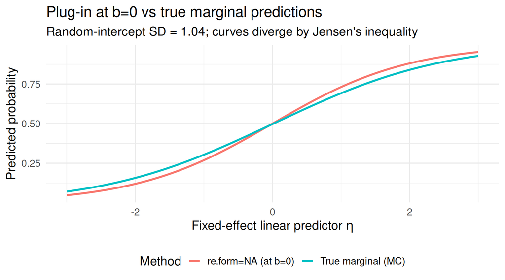

**Note**

**Reading it:** the marginal curve (averaged over $\mathbf{b}$) is **flatter / pulled toward 0.5** than the plug-in curve. The gap is largest where the logistic curve is most nonlinear and shrinks at the extremes. Flatter marginal = attenuated population-average effect.

## A Real FLW Case Study: Seizure Counts

**Note**

FLW Ch. 14 canonical example (Leppik et al. 1987; Thall & Vail 1990). Placebo-controlled trial of **progabide** in 59 epileptics. Baseline 8-week seizure count, then four 2-week post-randomization counts. Model and target match **FLW Table 14.5 / 14.6**.

- Outcome: seizure **count** per period, Poisson with **offset** $\log(T_{ij})$ ($T = 8$ wk baseline, $2$ wk follow-up)
- Random **intercept and slope** on Time (baseline vs follow-up): $q = 2$
- Question: does progabide reduce the subject-specific seizure rate?

## Load and Reshape the Seizure Data

```r
sz_url  <- "https://content.sph.harvard.edu/fitzmaur/ala2e/epilepsy.txt"
sz_file <- "../../data/epilepsy-data.txt"     # local copy (header stripped)
if (!file.exists(sz_file)) {
  raw <- readLines(url(sz_url))               # FLW file has a comment header
  dat <- raw[grepl("^\\s*[0-9]", raw)]        # keep numeric rows only
  writeLines(dat, sz_file)
}
sz_wide <- read.table(sz_file, header = FALSE,
  col.names = c("id", "trt", "age", "baseline", "y1", "y2", "y3", "y4"))

sz_long <- sz_wide %>%
  pivot_longer(c(baseline, y1, y2, y3, y4),
               names_to = "period_lab", values_to = "count") %>%
  mutate(
    period = recode(period_lab, baseline = 0L, y1 = 1L, y2 = 2L, y3 = 3L, y4 = 4L),
    Time   = if_else(period == 0L, 0L, 1L),         # 0 = baseline, 1 = follow-up
    Tij    = if_else(period == 0L, 8, 2),           # exposure weeks
    logT   = log(Tij),
    Trt    = trt                                    # 0 = placebo, 1 = progabide
  ) %>% arrange(id, period)
cat("Rows:", nrow(sz_long), " Subjects:", dplyr::n_distinct(sz_long$id), "\n")
```

## Load and Reshape the Seizure Data

```
Rows: 295  Subjects: 59
```

## Fit the Seizure GLMM (FLW Table 14.6)

```r
sz_fit <- glmer(
  count ~ Trt * Time + (1 + Time | id),
  offset = logT, data = sz_long,
  family = poisson(link = "log"),
  control = glmerControl(optimizer = "bobyqa")
)
broom.mixed::tidy(sz_fit, effects = "fixed", conf.int = TRUE) %>%
  dplyr::select(term, estimate, std.error, conf.low, conf.high)
```

**Note**

Reproduces FLW Table 14.6: Intercept $\approx$ 1.07, Time $\approx$ 0.00, Trt $\approx$ 0.05, **Trt$\times$Time $\approx$ -0.306** (FLW -0.3065), $\widehat{g}_{11}\approx$ 0.5 (FLW 0.50). Laplace matches the book’s 50-point quadrature here.

## Fit the Seizure GLMM (FLW Table 14.6)

```
# A tibble: 4 × 5
  term         estimate std.error conf.low conf.high
  <chr>           <dbl>     <dbl>    <dbl>     <dbl>
1 (Intercept)  1.07         0.140    0.796    1.35
2 Trt          0.0512       0.193   -0.326    0.429
3 Time        -0.000474     0.109   -0.214    0.213
4 Trt:Time    -0.306        0.150   -0.601   -0.0114
```

## Interpreting the Seizure Fit (subject-specific)

- All covariates are dichotomous, so $\exp(\beta)$ are **subject-specific (log) rate ratios** (FLW Table 14.5)
- $\exp(\beta_4)$ (Trt$\times$Time) is a **ratio of rate ratios**: progabide vs placebo change from baseline
- $\widehat{\beta}_4 = -0.306 < 0$: progabide reduces the seizure rate from baseline
- For a “typical” progabide patient ($b_{2i}=0$): rate ratio $e^{\widehat\beta_2 + \widehat\beta_4} \approx 0.74$ (about a 26% drop)

## Seizure Variance Components

```r
print(VarCorr(sz_fit), comp = c("Variance", "Std.Dev."))
```

**Note**

$\widehat{g}_{11} \approx$ 0.5 (baseline-rate heterogeneity) and a positive random-slope variance: patients differ in baseline rate **and** in how their rate changes over time, the FLW motivation for both random effects.

## Seizure Variance Components

```
 Groups Name        Variance Std.Dev. Corr
 id     (Intercept) 0.49987  0.70701
        Time        0.23195  0.48161  0.160
```

## The Same GLMM in SAS (reference)

Static reference (not run here): the seizure log-linear GLMM in `PROC GLIMMIX`, mirroring **FLW Table 14.11** (ML via adaptive quadrature).

```sas
proc glimmix data=seizure method=quad(qpoints=50);
   class id trt;
   model count = trt time trt*time / dist=poisson link=log solution
                 offset=logT;
   random intercept time / subject=id type=un;
run;
```

**Note**

`method=quad(qpoints=50)` is adaptive Gaussian quadrature (FLW’s choice); `random intercept time / subject=id type=un` is lme4’s `(1 + time | id)` with an unstructured $G$; `offset=logT` matches the R `offset`.

## Overdispersion Check

```r
pr  <- residuals(sz_fit, type = "pearson")
od  <- sum(pr^2) / df.residual(sz_fit)
cat("Overdispersion ratio (Pearson X^2 / df):", round(od, 2), "\n")
```

| Ratio | Reading |
| --- | --- |
| $\approx 1$ | Poisson variance adequate |
| $> 1.5$ | Overdispersion likely |
| $> 3$ | Serious overdispersion |

## Overdispersion Check

```
Overdispersion ratio (Pearson X^2 / df): 1.34
```

## Overdispersion Remedies

**Option 1 - observation-level random effect (OLRE):**

```r
sz_long$obs <- factor(seq_len(nrow(sz_long)))
glmer(count ~ Trt * Time + (1 + Time | id) + (1 | obs),
      offset = logT, data = sz_long, family = poisson)
```

**Option 2 - negative binomial (FLW Table 14.8):**

```r
glmmTMB::glmmTMB(count ~ Trt * Time + (1 + Time | id),
                 offset = logT, data = sz_long, family = nbinom2)
```

## Hypothesis Testing: Fixed Effects

- Wald tests (from `summary()`) are asymptotic; small clusters $\rightarrow$ prefer **profile likelihood**

```r
confint(sz_fit, parm = "beta_", method = "profile")  # profile CIs for fixed effects
```

## Hypothesis Testing: Variance Components

Testing $H_0$: random **slope** dropped ((1+Time|id) $\to$ (1|id)) removes **two** parameters (slope variance **and** intercept-slope covariance).

**Warning**

**Two boundary cases (Stram-Lee):**

- Drop a single random-**intercept** variance ($\sigma^2 = 0$): null is $\tfrac12\chi^2_0 + \tfrac12\chi^2_1$
- Drop a random **slope** from a RI+RS model (this Case Study): null is $\tfrac12\chi^2_1 + \tfrac12\chi^2_2$

`lme4`/`anova()` report the **naive** $\chi^2_2$ p-value; the mixture correction must be applied by hand.

**Warning**

`RLRsim::exactRLRT()` is for **linear (Gaussian)** mixed models only and is **not valid for GLMMs**. Use a **parametric-bootstrap LRT** instead.

## Parametric-Bootstrap LRT for the Random Slope

```r
null_fit <- glmer(count ~ Trt * Time + (1 | id), offset = logT,
                  data = sz_long, family = poisson,
                  control = glmerControl(optimizer = "bobyqa"))
lr_obs <- as.numeric(2 * (logLik(sz_fit) - logLik(null_fit)))

set.seed(667)
B <- 100
sim_y   <- simulate(null_fit, nsim = B)          # simulate under the null
lr_boot <- vapply(seq_len(B), function(b) {
  f0 <- refit(null_fit, newresp = sim_y[[b]])
  f1 <- refit(sz_fit,  newresp = sim_y[[b]])
  as.numeric(2 * (logLik(f1) - logLik(f0)))
}, numeric(1))

p_boot <- (1 + sum(lr_boot >= lr_obs)) / (1 + B)
p_mix  <- 0.5 * pchisq(lr_obs, 1, lower.tail = FALSE) +
          0.5 * pchisq(lr_obs, 2, lower.tail = FALSE)
cat("LR statistic:        ", round(lr_obs, 2), "\n")
```

## Parametric-Bootstrap LRT for the Random Slope

```
LR statistic:         171.87
```

```r
cat("Naive chi^2_2 p:     ", round(pchisq(lr_obs, 2, lower.tail = FALSE), 4), "\n")
```

```
Naive chi^2_2 p:      0
```

```r
cat("Stram-Lee mixture p: ", round(p_mix, 4), "\n")
```

```
Stram-Lee mixture p:  0
```

```r
cat("Parametric bootstrap p (B=", B, "): ", round(p_boot, 4), "\n", sep = "")
```

```
Parametric bootstrap p (B=100): 0.0099
```

## Post-Hoc Contrasts with emmeans

```r
emm_contrasts <- emmeans(glmm_fit, specs = pairwise ~ treat | weeks,
                         at = list(weeks = c(0, 48)), type = "response")
summary(emm_contrasts$contrasts)
```

## Post-Hoc Contrasts with emmeans

```
weeks = 0:
 contrast        odds.ratio    SE  df null z.ratio p.value
 Usual / Steroid      0.366 0.112 Inf    1  -3.279  0.0010

weeks = 48:
 contrast        odds.ratio    SE  df null z.ratio p.value
 Usual / Steroid      0.446 0.113 Inf    1  -3.196  0.0014

Results are averaged over the levels of: severity
Tests are performed on the log odds ratio scale
```

## Interpreting emmeans Contrasts

These are **subject-specific** odds ratios evaluated at $\mathbf{b}_i = 0$ (the **median** subject on the logit scale), **NOT** the population-average OR.

- At $\mathbf{b}_i = 0$ = conditional on the median latent subject
- The population-average OR is **attenuated** (Jensen); see the **Three Types of Predictions** table
- Do **not** read these as “the average subject in the population”

## Random-Effects Heterogeneity (seizure slopes)

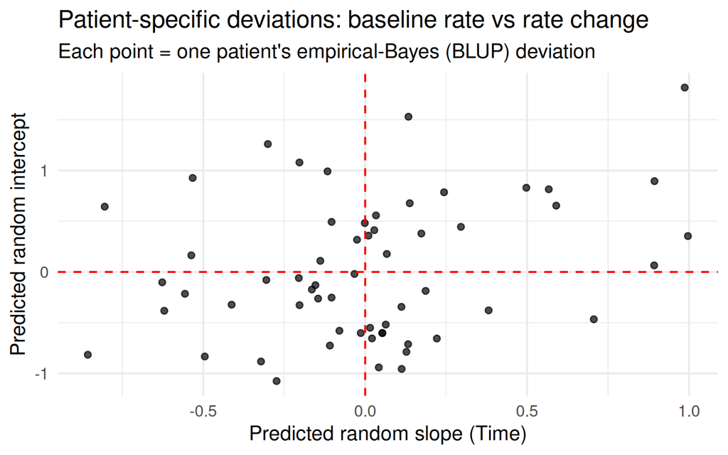

**Note**

**Reading it:** spread along the vertical axis = baseline-rate heterogeneity ($g_{11}$); spread along the horizontal = heterogeneity in the rate change ($g_{22}$). The mild positive tilt is the small positive $g_{12}$ (FLW 0.054).

## Diagnostics: Residuals vs Fitted

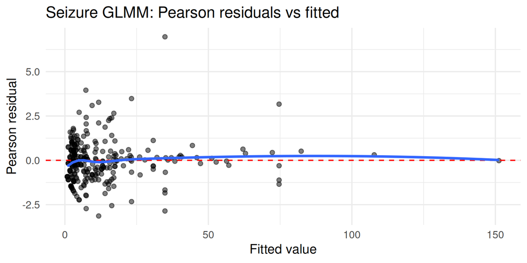

**Note**

**Reading it:** good = a flat, structureless band around the red zero line. **Bad** = a funnel (variance grows with the mean $\to$ overdispersion) or curvature in the blue smoother (mean misspecified). A few large positive residuals here trace to the high-count patients (e.g. patient 49).

## Diagnostics: Random-Effects Q-Q

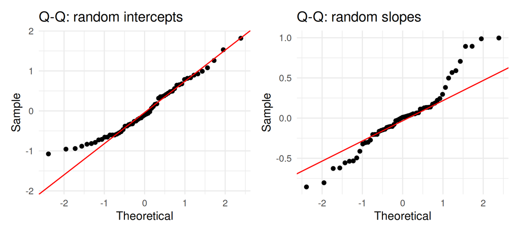

**Warning**

**Reading it (with a caveat):** points near the line support $\mathbf{b}_i \sim N(0,G)$; heavy tails or curvature suggest non-normal random effects. **But** these are empirical-Bayes (BLUP) predictions, which are **shrunk toward 0 and toward normality**, so a clean Q-Q plot **understates** non-normality. Treat it as a weak check (FLW Ch. 14.2).

## Convergence Troubleshooting Recipe

| Warning | First fix |
| --- | --- |
| “failed to converge” | **Rescale** continuous predictors (`scale()`) |
| “nearly unidentifiable” | **Simplify** $G$: drop a near-zero random slope |
| “singular fit” (variance $\approx 0$) | Use **uncorrelated** REs: `(1\|id) + (0 + x\|id)` |
| slow / stuck | **Switch optimizer**: `glmerControl(optimizer = "bobyqa")` |
| separation (binary) | Bayesian priors (`brms`) or penalized likelihood (`brglm`) |

**Rule of thumb:** if a random-slope variance is $< 0.01$ and convergence struggles, drop it.

```r
# Rescaling the continuous predictor often resolves convergence trouble.
asthma_dat$weeks_z <- as.numeric(scale(asthma_dat$weeks))
fit_scaled <- glmer(control ~ treat * weeks_z + severity + (weeks_z | id),
                    data = asthma_dat, family = binomial,
                    control = glmerControl(optimizer = "bobyqa"))
cat("Converged:", is.null(fit_scaled@optinfo$conv$lme4$messages), "\n")
```

```
Converged: FALSE
```

```r
cat("Random-slope SD:",
    round(as.data.frame(VarCorr(fit_scaled))$sdcor[2], 3), "\n")
```

```
Random-slope SD: 0.178
```

## Common Pitfalls and Remedies

| Pitfall | Remedy |
| --- | --- |
| Treating $\beta$ as a marginal effect | It is **conditional**; use Zeger (Ch. 16) for the marginal effect |
| `re.form=NA` read as marginal mean | It is $E(Y\mid\mathbf{b}=0)$; integrate over $\mathbf{b}$ (Monte Carlo) |
| Comparing GLMM and GEE ORs as if equal | Different estimands; both valid for their question |
| `exactRLRT` for a GLMM variance test | Gaussian-LMM only; use a **parametric bootstrap** |
| Wrong boundary mixture | Match params dropped: 1 var $\to \tfrac12\chi^2_0+\tfrac12\chi^2_1$; slope $\to \tfrac12\chi^2_1+\tfrac12\chi^2_2$ |
| Near-singular $G$ | Reduce random slopes; center/scale covariates |
| Ignoring convergence warnings | Rescale, simplify $G$, switch optimizer |

## Reporting Checklist

- State **“conditional on the random effects”** (or “within-subject”) when interpreting $\beta$
- Report the **estimand**: conditional OR/RR, and the marginal version if relevant
- Report **variance components** with CIs
- State the **estimation method** (Laplace, nAGQ = X, or MCMC)
- For variance-component tests, state the **mixture / bootstrap** used

**Quick Check**

A colleague reports “treatment increased the odds 2.5-fold (OR = 2.5)” from a logistic GLMM. What is missing?

**Answer:** the frame of reference. It is a **conditional** (within-subject) OR. Complete: “Within a given subject, treatment increased the odds 2.5-fold (conditional OR = 2.5, 95% CI …); the population-average OR is approximately [Zeger].”

## Extensions and Software

| Extension (Ch. 14) | Software note |
| --- | --- |
| Negative-binomial / zero-inflated counts | `glmmTMB` (FLW Table 14.8) |
| Crossed random effects | `lme4` `(1\|a) + (1\|b)` |
| Bayesian GLMMs (full posterior) | `brms`, `MCMCglmm` |
| Selection of fixed + random effects | `glmmPen` (penalized MCEM) |

## Wrap-Up

- GLMM = GLM plus latent subject effects; inference is **subject-specific (conditional)**
- The marginal effect is **attenuated** (Jensen / non-collapsibility); Zeger approximates it (Ch. 16)
- Fit by **ML** (Laplace / adaptive quadrature); valid under **MAR**
- `re.form=NA` is conditional at $\mathbf{b}=0$, **not** marginal; integrate for true marginal
- Test variance components with the **right mixture** or a **parametric bootstrap** (never `exactRLRT` for a GLMM)
- **Next chapter (Ch. 15):** approximate likelihood methods (PQL/MQL) and their tradeoffs

## Reading

**Required:** Fitzmaurice et al. Ch. 14, sections 14.1-14.6, plus the Appendix on adaptive Gaussian quadrature.

**Optional:**

- Zeger, Liang & Albert (1988), marginal vs subject-specific approximation (the 0.346 factor; see FLW Ch. 16)
- Bolker et al. (2009), GLMMs: a practical guide